# Power Calculations

Steve Pederson

03/05/2021

```r
library(tidyverse)
library(readxl)
library(zoo)
library(truncnorm)
library(parallel)
library(scales)
library(glue)
library(magrittr)
library(pander)
```

```r
theme_set(theme_bw())
```

# Ki67 data

The common measurement of Ki67 data is as a percentage of cells staining +ve for Ki67. Example data is taken from PDX samples in the Nature Medicine paper.

```r
ki67_natmed <- here::here("41591_2020_1168_MOESM3_ESM.xlsx") %>%
    read_excel(sheet = "S1d") %>%
    setNames(
        tibble(
            names = colnames(.),
            r1 = unlist(.[1,])
        ) %>%
            mutate(
                names = str_replace_all(names, "\\.\\.\\.+", NA_character_),
                names = na.locf(names)
            ) %>%
            unite(names, names, r1, sep = " ") %>%
            pull(names) %>%
            str_remove_all(" NA$")
    ) %>%
    dplyr::slice(-1) %>%
    dplyr::filter(!str_detect(Diagnosis, "Normal"))
```

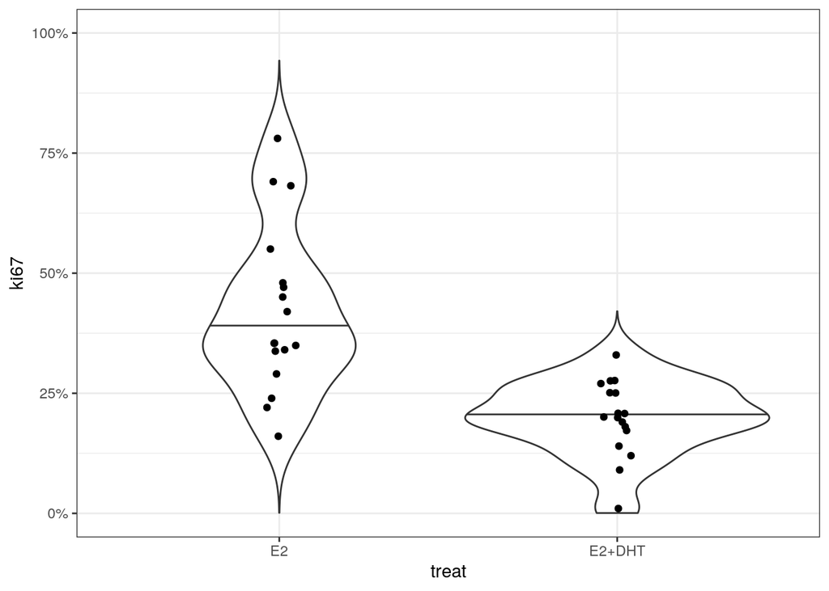

```r
ki67_natmed %>%
    dplyr::select(`Sample ID`, contains("Ki67")) %>%
    pivot_longer(
        cols = contains("E2"),
        names_to = "treat",
        values_to = "ki67"
    ) %>%
    mutate(
        treat = str_remove_all(treat, "Ki67.+\\(%\\) "),
        ki67 = as.numeric(ki67)/100,
        # ki67 = binomial()$linkfun(ki67)
        # ki67 = log(ki67)
    ) %>%
    ggplot(
        aes(treat, ki67)
    ) +
    geom_violin(
        draw_quantiles = 0.5,
        trim = FALSE
    ) +
    geom_jitter(width = 0.05) +
    scale_y_continuous(limits = c(0, 1), labels = percent)
```

```r
ki67_natmed %>%
  dplyr::select(`Sample ID`, contains("Ki67")) %>%
  pivot_longer(
    cols = contains("E2"),
    names_to = "treat",
    values_to = "ki67"
  ) %>%
  mutate(
    treat = str_remove_all(treat, "Ki67.+\\(%\\) "),
    ki67 = as.numeric(ki67)/100
  ) %>%
  group_by(
    treat
  ) %>%
  summarise(
    n = n(),
    across(.cols = contains("ki67"), .fns = list(mean = mean, median = median, sd = sd)),
    .groups = "drop"
  ) %>%
  rename_all(str_replace_all, pattern = "_", replacement = " ") %>%
  rename_all(str_to_title) %>%
  pander(
    caption = "Summary statistics from PDX Ki67 data"
  )
```

Summary statistics from PDX Ki67 data

| Treat | N | Ki67 Mean | Ki67 Median | Ki67 Sd |
| --- | --- | --- | --- | --- |
| E2 | 17 | 0.4216 | 0.3541 | 0.1729 |
| E2+DHT | 17 | 0.1984 | 0.2 | 0.0783 |

Given the above plot, a truncated normal distribution may be suitable for simulation of data. Note that we’ll be using the Wilcoxon, so the exact distributional patterns are less relevant. Compare some simulated data to the real data.

In the following the value provided for sd will track the initial sd, but diminishing in a sqrt pattern. This in essence follows the pattern of a linear reduction for variance (σ^2). For example, for a 50% reduction in Ki67, the sd for the reduced sample will be √(1 - 0.5)σ. Likewise for a 70% reduction, the sd for simulation will be √(1 - 0.7)σ.

```r
ki0 <- 0.4
n <- 20
sigma <- 0.2
```

Based on the observed PDX data, start with σ = 0.2, an initial Ki67 value of 0.4, simulating 20 observations per group. Whilst σ = 0.2 is higher than that in the observed data, it should be noted that for a truncated normal, the observed sd will have a bias to be lower than the provided value. By way of example, simulating 20 point 1000 times, returned a median sd of 0.184. Using the sqrt function for the sd of reduced Ki67 data may again be conservative, but for power calculations it is best to err on the side of caution.

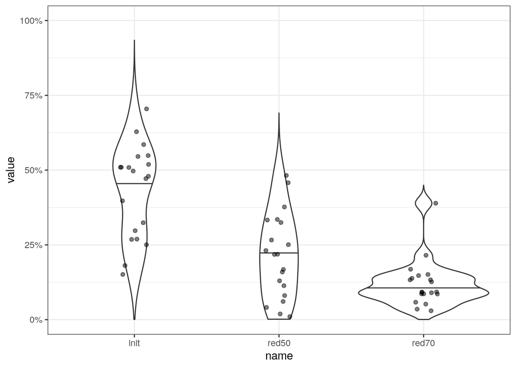

```r
tibble(
    init = rtruncnorm(n, 0, 1, ki0, sigma),
    red50 = rtruncnorm(n, 0, 1, 0.5*ki0, sqrt(0.5)*sigma),
    red70 = rtruncnorm(n, 0, 1, (1 - 0.7)*ki0, sqrt(1 - 0.7)*sigma)
) %>%
    pivot_longer(cols = everything()) %>%
    ggplot(aes(name, value)) +
    geom_violin(draw_quantiles = 0.5, trim = FALSE) +
    geom_jitter(width = 0.1, alpha = 0.5) +
    scale_y_continuous(limits = c(0, 1), labels = percent)
```

To generate a power curve, we need power on the y-axis, `n` on the x-axis with different starting values for ki0. Importantly, power was estimated using α = 0.017 as the threshold for significance, given we require multiple testing to be taken into account, and we have three comparisons.

```r
power_fun <- function(n1, n2, init, reduction, sd = 0.2, alpha = 0.05/3, n_sim = 1e4){
    p <- replicate(
        n_sim,
        {
            y1 <- rtruncnorm(n1, a = 0, b = 1, mean = init, sd = sd)
            y2 <- rtruncnorm(n2, a = 0, b = 1, mean = (1-reduction)*init, sd = sqrt(1-reduction)*sd)
            wilcox.test(y1, y2)$p.value <= alpha
        }
    )
    mean(p)
}
```

Data was simulated using equal sized groups for control & treatment, as well as having double the samples in the treatment arm. Sample sizes were incremented in steps of 5.

Initial values for Ki67 were simulated as ranging from 10% to 30%, with a reduction from 50 to 70% being simulated. Both were incremented in steps of 10%.

```r
n2_ratio <- c(1, 2)
n <- rep(
    seq(10, 50, by = 5),
    length(n2_ratio)
)
core_df <- tibble(
    n1 = n,
    ratio = rep(n2_ratio, each = length(unique(n))),
    n2 = floor(n1*ratio)
)
power_sim <- list(
    mutate(core_df, init = 0.1, reduction = 0.5),
    mutate(core_df, init = 0.2, reduction = 0.5),
    mutate(core_df, init = 0.3, reduction = 0.5),
    mutate(core_df, init = 0.1, reduction = 0.6),
    mutate(core_df, init = 0.2, reduction = 0.6),
    mutate(core_df, init = 0.3, reduction = 0.6),
    mutate(core_df, init = 0.1, reduction = 0.7),
    mutate(core_df, init = 0.2, reduction = 0.7),
    mutate(core_df, init = 0.3, reduction = 0.7)
) %>%
    bind_rows() %>%
    split(f = seq_along(.$n1)) %>%
    mclapply(
        function(x){
            pwr <- power_fun(
                n1 = x$n1,
                n2 = x$n2,
                init = x$init,
                reduction = x$reduction,
                n_sim = 1e4
            )
            mutate(x, pwr = pwr)
        },
        mc.cores = 8
    ) %>%
    bind_rows()
```

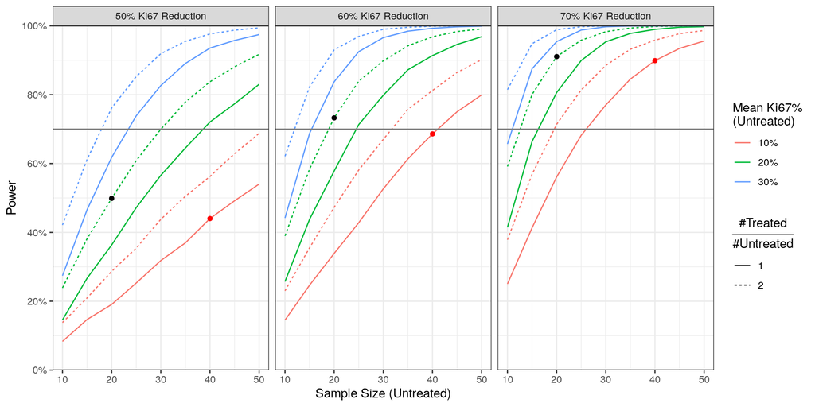

*Power curve for 50, 60 and 70% Ki67 reduction. Black dots indicate the estimated power for control vs treatment, whilst red dots indicate estimated power for comparison between treatment arms.*

```r
power_sim %>%
    mutate(
        reduction = glue("{percent(reduction)} Ki67 Reduction"),
        init = percent(init),
    ) %>%
    ggplot(
        aes(n1, pwr, colour = init, linetype = as.factor(ratio))
    ) +
    geom_line() +
    geom_hline(yintercept = 0.7, colour = "grey50") +
    geom_point(
        aes(n1, pwr),
        data = . %>%
            dplyr::filter(
                n1 == 20, ratio == 2, init == "20%"
            ),
        colour = "black"
    ) +
    geom_point(
        aes(n1, pwr),
        data = . %>%
            dplyr::filter(
                n1 == 40, ratio == 1, init == "10%"
            ),
        colour = "red"
    ) +
    facet_wrap(~as.factor(reduction)) +
    labs(
        x = "Sample Size (Untreated)",
        y = "Power",
        colour = "Mean Ki67%\n(Untreated)",
        linetype = expression(frac("#Treated", "#Untreated"))
    ) +
    theme(
        plot.title = element_text(hjust = 0.5)
    ) +
    scale_y_continuous(
        limits = c(0, 1),
        expand = expansion(c(0, 0)),
        labels = percent,
        breaks = seq(0, 1, length.out = 6)
    )
```

When comparing between already reduced Ki67 positivity in the two treatment arms, this will provide a power of 70% to detect a reduction of 60% or more between the two treatment groups. This assumes a lower initial positivity (~10%) in the higher of the two treatment arms.

# CT Scans

Assuming that dogs from the above treatment arms go forward into the next step of the experiment, we need to assess the probability of relapse, and our ability to detect difference. According to the McEwen paper, the 100 day probability of being cancer-free for dogs with tumour volumes > 40cc is 50% of patients.

If we assume the above sample sizes (i.e. 20 control and 40 in the treatment arm), we can perform a Fisher’s Exact Test, given that this is sampling without replacement. Data was simulated using a binomial distribution, simulating the number of dogs with a relapse for a given probability. Power was then estimated using Fisher’s Exact Test for a difference between the control group and the treatment arm. Data for the treatment arm was simulated using the same process, but with a reduced probability of recurrence.

```r
fisher_fun <- function(p1, n1, n2, improvement, n_sim = 1e3, alpha = 0.05){
    res <- replicate(
        n_sim,
        {
            d1 <- rbinom(1, n1, p1) # The estimated recurrence (which is success in this modelling approach)
            ## The treatment group
            p2 <- (1 - improvement)*p1
            d2 <- rbinom(1, n2, p2)
            c(d1, n1-d1) %>%
                rbind(c(d2, n2 - d2)) %>%
                set_colnames(c("relapse", "survival")) %>%
                set_rownames(c("control", "treat")) %>%
                fisher.test() %>%
                .[["p.value"]] %>%
                is_less_than(alpha)
        }
    )
    mean(res)
}
```

```r
core_df <- tibble(
    n1 = c(15, 20, 30, 40, 50),
    n2 = c(30, 40, 30, 40, 50),
    p1 = 0.5
)
fisher_res <- list(
    mutate(core_df, improvement = 0.3),
    mutate(core_df, improvement = 0.4),
    mutate(core_df, improvement = 0.5),
    mutate(core_df, improvement = 0.6),
    mutate(core_df, improvement = 0.7),
    mutate(core_df, improvement = 0.8)
) %>%
    bind_rows() %>%
    split(f = seq_along(.$n1)) %>%
    mclapply(
        function(x){
            pwr <- fisher_fun(p1 = x$p1, n1 = x$n1, n2 = x$n2, improvement = x$improvement, n_sim = 5e3)
            mutate(x, pwr = pwr)
        },
        mc.cores = 6
    ) %>%
    bind_rows() %>%
    mutate(ss = glue("({n1}, {n2})"))
```

The power curve below reveals that:

- For the smallest combination (n<sub>c</sub> = 15, n~treat = 30), a 70% power will only be obtained if the improvement in the 100-day cancer free rate is 73%, i.e. it drops from 50% to 13.5% recurrence
- Using n<sub>c</sub> = 50, n<sub>treat</sub> = 50 gives an estimated power of 70% if the improvement is only 52%, i.e. a drop from 50% to 24% recurrence
- For an improvement beyond 75% (i.e. 50% down to 12.5% recurrence), all sample sizes return a power ≥70%

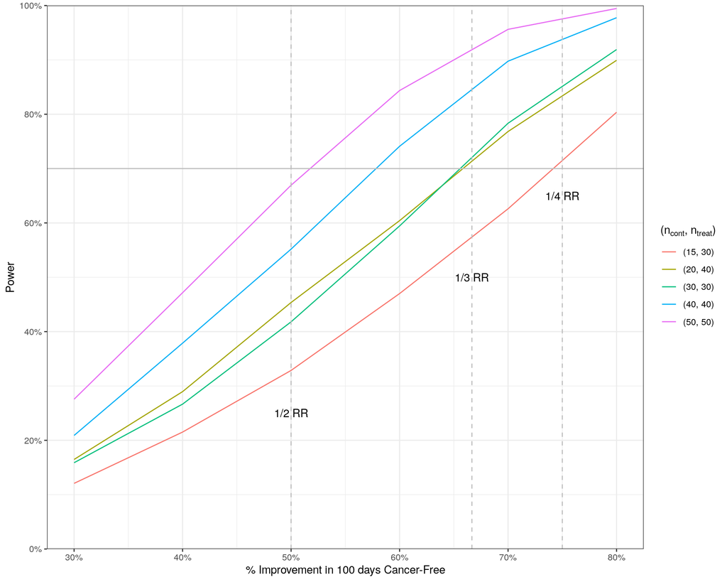

*Power estimates for various sample sizes based on a control and treatment group. The parameter being measured is the % improvement in the 100-day cancer-free rate. The 100-day cancer-free rate in untreated tumours was set as 50% based on the paper by McEwen. Dashed vertical lines denote half, 1/3 and 1/4 the numbers of patients showing relapse (relative relapse = RR)*

```r
my_percent <- function(x){
    percent(x, accuracy = 1)
}
fisher_res %>%
  ggplot(
    aes(improvement, pwr, colour = as.factor(ss))
  ) +
  geom_line() +
  geom_hline(yintercept = 0.7, colour = "grey") +
  geom_vline(
    xintercept = c(0.5, 2/3, 3/4),
    linetype = 2,
    colour = "grey"
  ) +
  geom_text(
    aes(x, y, label = lab),
    data = tibble(
      x = c(1/2, 2/3, 3/4),
      y = c(0.25, 0.5, 0.65),
      lab = c("1/2 RR", "1/3 RR", "1/4 RR")
    ),
    inherit.aes = FALSE
  ) +
  scale_x_continuous(
    labels = my_percent,
    breaks = seq(0, 1, by = 0.1),
  ) +
  scale_y_continuous(
    limits = c(0, 1),
    expand = expansion(c(0, 0)),
    labels = percent,
    breaks = seq(0, 1, length.out = 6)
  ) +
  labs(
    x = "% Improvement in 100 days Cancer-Free",
    y = "Power",
    colour = expression(paste("(", n[cont], ", ", n[treat], ")"))
  )
```

# Conclusion

This would allow taking 3/4 of dogs forward into the CT scan section of the study. Using n<sub>i</sub> = 30 gives a power ≥70% to detect a change in the proportion of dogs showing recurrence to being ≤1/3 of what is observed in the untreated group. This can also be explained as a 66% reduction in the recurrence rate.

Increasing this to n<sub>i</sub>=40 for each CT scan group would return a power of ≥70% to detect a reduced recurrence to be 43% of what is observed in the control group (i.e. a reduction of 57% in the recurrence rate).